# Predict Housing Value

Ziyi GUO, Junyi Yang

## Data Wrangling

1. read in the initial housing data,

```r
# initial housing data
housingData <-
  read.csv(file.path("./dataWithoutcrime/kc_house_data.csv"))

Seattle.sf <-
  housingData %>%
  st_as_sf(coords = c("long", "lat"), crs = 4326, agr = "constant") %>%
  st_transform(crs = 2926) %>%
  mutate(price_per_sqft = price / sqft_lot)

# Seattle geo_Tracts
tracts <-
  st_read("./dataWithoutcrime/2010_Census_Tract_Seattle.geojson") %>%
  st_transform(crs = 2926)
#Cut the housing data to fit into the Seattle boundary
Seattle.sf_tracts <- st_intersection(Seattle.sf, tracts)
Seattle.sf_tracts2 <- Seattle.sf_tracts %>%
  select(id, date, price ,bedrooms, bathrooms, sqft_living, sqft_lot, floors, waterfront, view, condition, grade, yr_built, yr_renovated, zipcode, price_per_sqft, geometry)


# Add-in Data

# Seattle neighborhood
neighborhood <-
  st_read("./dataWithoutcrime/Neighborhood_Map.geojson") %>%
  st_transform(crs = 2926)
## social
crime <- read.csv(file.path("SPD_Crime_Data__2008-Present_20240319.csv"))

Crime.sf <-
  crime %>%
  st_as_sf(coords = c("Longitude", "Latitude"), crs = 4326, agr = "constant") %>%
  st_transform(crs = 2926)


## Amenities
School <-
  st_read("./dataWithoutcrime/Private_School.geojson") %>%
  st_transform(crs = 2926)
Parks <-
  st_read("./dataWithoutcrime/seattle-parks-osm.geojson") %>%
  st_transform(crs = 2926)
Hospital <-
  st_read("./dataWithoutcrime/Hospital.geojson") %>%
  st_transform(crs = 2926)
## Streetcar
streetcar <-
  st_read("./dataWithoutcrime/streetcar_3857.geojson") %>%
  st_transform(crs = 2926)
## Traffic flow
traffic <-
  st_read("./dataWithoutcrime/traffic_3857.geojson") %>%
  st_transform(crs = 2926)
## canopy
canopy <-
  st_read("./dataWithoutcrime/tree_3857.geojson") %>%
  st_transform(crs = 2926)
## Crosswalk
crosswalk <-
  st_read("./dataWithoutcrime/Marked_Crosswalks.geojson") %>%
  st_transform(crs = 2926)
```

```
## replacing null geometries with empty geometries
## Simple feature collection with 6335 features and 60 fields (with 42 geometries empty)
## Geometry type: POINT
## Dimension:     XY
## Bounding box:  xmin: 1249042 ymin: 185194.5 xmax: 1292399 ymax: 271493.6
## Projected CRS: NAD83(HARN) / Washington North (ftUS)
```

## Clean Safety data

```r
Seattle.sf_tracts2$crime.Buffer <- Seattle.sf_tracts2 %>%
    st_buffer(660) %>%
    aggregate(dplyr::select(Crime.sf) %>%
    mutate(counter = 1), ., sum)

## Nearest Neighbor Feature
Seattle.sf_tracts2 <-
  Seattle.sf_tracts2 %>%
    mutate(
      crime_nn1 = nn_function(st_coordinates(Seattle.sf_tracts2),
                              st_coordinates(Crime.sf), k = 1),

      crime_nn2 = nn_function(st_coordinates(Seattle.sf_tracts2),
                              st_coordinates(Crime.sf), k = 2),

      crime_nn3 = nn_function(st_coordinates(Seattle.sf_tracts2),
                              st_coordinates(Crime.sf), k = 3),

      crime_nn4 = nn_function(st_coordinates(Seattle.sf_tracts2),
                              st_coordinates(Crime.sf), k = 4),

      crime_nn5 = nn_function(st_coordinates(Seattle.sf_tracts2),
                              st_coordinates(Crime.sf), k = 5))
```

## Schools

```r
#count the school number within the buffer
Seattle.sf_tracts2$school.Buffer <- Seattle.sf_tracts2 %>%
    st_buffer(5280) %>%
    aggregate(dplyr::select(School ) %>%
    mutate(counter = 1), ., sum)

## Nearest Neighbor Feature
Seattle.sf_tracts2 <-
  Seattle.sf_tracts2 %>%
    mutate(
      school_nn1 = nn_function(st_coordinates(Seattle.sf_tracts2),
                              st_coordinates(School), k = 1),
      )
```

## Hospitals

```r
Seattle.sf_tracts2$hosp.Buffer <- Seattle.sf_tracts2 %>%
    st_buffer(5280) %>%
    aggregate(dplyr::select(Hospital) %>%
    mutate(counter = 1), ., sum)

## Nearest Neighbor Feature
Seattle.sf_tracts2 <-
  Seattle.sf_tracts2 %>%
    mutate(
      hosp_nn1 = nn_function(st_coordinates(Seattle.sf_tracts2),
                              st_coordinates(Hospital), k = 1))
```

## Parks

```r
#Parks are polygon hard to get distance
Seattle.sf_tracts2$parks.Buffer <- Seattle.sf_tracts2 %>%
    st_buffer(1320) %>%
    aggregate(dplyr::select(Parks) %>%
    mutate(counter = 1), ., sum)
```

## crosswalk

```r
#Parks are polygon hard to get distance
Seattle.sf_tracts2$crosswalk.Buffer <- Seattle.sf_tracts2 %>%
    st_buffer(1320) %>%
    aggregate(dplyr::select(crosswalk) %>%
    mutate(counter = 1), ., sum)
```

## Streetcar stations

```r
# Streetcar buffer
streetcar.Buffer <- st_union(st_buffer(streetcar, dist=1000))

# Assign to overall dataframe
Seattle.sf_tracts2$streetcar.station <- st_within(Seattle.sf_tracts2, streetcar.Buffer) %>% lengths > 0
```

## canopy

```r
# join canopy to housing points
Seattle.sf_tracts3 <- st_join(Seattle.sf_tracts2, canopy, left = TRUE)

Seattle.sf_tracts3 <- Seattle.sf_tracts3 %>%
  st_drop_geometry() %>%
  select(id, Can_P)

# put the column into the overall dataframe
Seattle.sf_tracts2$canopy <- Seattle.sf_tracts3["Can_P"]
```

## distance to major roads

```r
# traffic_relation <- nearestsegment(as.ppp(Seattle.sf_tracts2), as.psp(traffic))


# Convert Seattle.sf_tracts2 to a point pattern, specifying mark column(s)
Seattle_points <- as.ppp(Seattle.sf_tracts2)
# Convert traffic to a line segment pattern
traffic_lines <- as.psp(traffic)

# Find nearest line segment to each point
nearest_segments <- nncross(Seattle_points, traffic_lines)

# put the column into the overall dataframe
Seattle.sf_tracts2$distance <- nearest_segments['dist']
```

## Demographics

```r
Demo <- get_acs(geography = "tract",
          survey = "acs5",
          variables = c("B01001_001E", "B01001A_001E", "B06011_001E"),
          year = 2015,
          state = "53",
          county = "033",
          geometry = T,
          output = "wide") %>%
  st_transform(crs = 2926) %>%
  rename(TotalPop = B01001_001E,
         NumberWhites = B01001A_001E,
         MedIncome = B06011_001E) %>%
  mutate(pctWhite = NumberWhites / TotalPop)%>%
  select(-NAME, -GEOID)
Demo <- st_transform(Demo, st_crs(Seattle.sf_tracts2))

## Finalize the tracts2 data
#Join the demographics data
#Clean the data

Seattle.sf_tracts2 <- st_join(Seattle.sf_tracts2, Demo, left = TRUE)
Seattle.sf_tracts2 <- Seattle.sf_tracts2 %>%
  select(-contains("B01"), -contains("B06"))%>%
  mutate(Age = 2024 - yr_built, parksCount = parks.Buffer$counter, crimeCount=crime.Buffer$counter, schoolCount=school.Buffer$counter, hospitalCount=hosp.Buffer$counter, crosswalkCount=crosswalk.Buffer$counter, canopyPercent=canopy$Can_P, TrafficDis=distance$dist)
```

## Summarize and preview the variables

Categorized, summarized.

```r
## delete the geometry column
table_Seattle <- Seattle.sf_tracts2 %>% st_drop_geometry()

#category of the data

#internal_character
internal_character_df <- table_Seattle[, c("bedrooms", "bathrooms", "sqft_living","sqft_lot", "floors", "condition", "grade")]
internal_character <- round(do.call(cbind, lapply(internal_character_df, summary)), digits = 2)

#Structure_character
Structure_character_df <- table_Seattle[, c("condition", "grade", "Age", "yr_renovated")]
Structure_character <- round(do.call(cbind, lapply(Structure_character_df, summary)), digits = 2)

#amenities
amenities_df <- table_Seattle[, c("parksCount", "schoolCount", "hospitalCount", "crosswalkCount", "canopyPercent", "hosp_nn1", "school_nn1")]
amenities <- round(do.call(cbind, lapply(amenities_df, summary))[1:6,], digits = 2)
```

```r
#distance column for some reason need to be calculated separatly
distance_extract_df <- table_Seattle[, c("distance")]
distance_extract <- round(do.call(cbind, lapply(distance_extract_df, summary)), digits = 2)

amenities_all <- cbind(amenities, distance_extract)


#spatial_character
spatial_character_df <- table_Seattle[, c( "waterfront", "view")]
spatial_character <- round(do.call(cbind, lapply(spatial_character_df, summary)), digits = 2)

#safety
safety_df <- table_Seattle[, c( "crime_nn1","crime_nn2","crime_nn3","crime_nn4","crime_nn5", "crimeCount")]
safety <- round(do.call(cbind, lapply(safety_df, summary)), digits = 2)

#Demographics
Demographics_df <- table_Seattle[, c( "TotalPop", "MedIncome", "pctWhite")]
Demographics <- round(do.call(cbind, lapply(Demographics_df, summary))[1:6,], digits = 2)


# Combine the summaries into one data frame
summary_data <- cbind(internal_character, Structure_character, amenities_all,
                      spatial_character, safety, Demographics)

long_summary_data <- as.data.frame(t(summary_data)) %>%
  rename('Minimum' = 'Min.',
         '1st Quantile' = '1st Qu.',
         '3rd Quantile' = '3rd Qu.',
         'Maximun' = 'Max.')

#generate table
kbl(long_summary_data, caption = "Statistics Summary") %>%
  kable_styling(bootstrap_options = c("striped", "hover", "condensed")) %>%
  pack_rows("Internal Character", 1, 7) %>%
  pack_rows("Structure Character", 8, 11) %>%
  pack_rows("Amenities", 12, 19) %>%
  pack_rows("Spatial character", 20, 21) %>%
  pack_rows("Safety", 22, 27) %>%
  pack_rows("Demographics", 28, 30)
```

Statistics Summary

|  | Minimum | 1st Quantile | Median | Mean | 3rd Quantile | Maximun |
| --- | --- | --- | --- | --- | --- | --- |
| **Internal Character** |  |  |  |  |  |  |
| bedrooms | 0.00 | 2.00 | 3.00 | 3.14 | 4.00 | 33.00 |
| bathrooms | 0.00 | 1.00 | 1.75 | 1.94 | 2.50 | 8.00 |
| sqft_living | 370.00 | 1240.00 | 1626.00 | 1801.79 | 2200.00 | 12050.00 |
| sqft_lot | 520.00 | 3240.00 | 4950.00 | 5124.03 | 6330.00 | 91681.00 |
| floors | 1.00 | 1.00 | 1.50 | 1.54 | 2.00 | 3.50 |
| condition | 1.00 | 3.00 | 3.00 | 3.45 | 4.00 | 5.00 |
| grade | 4.00 | 7.00 | 7.00 | 7.43 | 8.00 | 13.00 |
| **Structure Character** |  |  |  |  |  |  |
| condition.1 | 1.00 | 3.00 | 3.00 | 3.45 | 4.00 | 5.00 |
| grade.1 | 4.00 | 7.00 | 7.00 | 7.43 | 8.00 | 13.00 |
| Age | 9.00 | 37.00 | 77.00 | 70.68 | 99.00 | 124.00 |
| yr_renovated | 0.00 | 0.00 | 0.00 | 132.46 | 0.00 | 2015.00 |
| **Amenities** |  |  |  |  |  |  |
| parksCount | 1.00 | 1.00 | 2.00 | 2.31 | 3.00 | 16.00 |
| schoolCount | 1.00 | 2.00 | 3.00 | 3.82 | 5.00 | 14.00 |
| hospitalCount | 1.00 | 1.00 | 1.00 | 1.32 | 1.00 | 5.00 |
| crosswalkCount | 1.00 | 5.00 | 10.00 | 12.12 | 16.00 | 83.00 |
| canopyPercent | 4.23 | 23.12 | 27.72 | 29.08 | 34.04 | 60.40 |
| hosp_nn1 | 292.19 | 5682.65 | 8541.55 | 9942.49 | 12788.58 | 25810.66 |
| school_nn1 | 52.05 | 1525.20 | 2449.55 | 2954.18 | 3800.21 | 17319.46 |
| dist | 0.04 | 157.94 | 319.35 | 402.60 | 551.22 | 2840.94 |
| **Spatial character** |  |  |  |  |  |  |
| waterfront | 0.00 | 0.00 | 0.00 | 0.00 | 0.00 | 1.00 |
| view | 0.00 | 0.00 | 0.00 | 0.29 | 0.00 | 4.00 |
| **Safety** |  |  |  |  |  |  |
| crime_nn1 | 3.68 | 75.27 | 106.82 | 113.57 | 145.36 | 603.42 |
| crime_nn2 | 3.68 | 77.55 | 109.34 | 115.69 | 148.09 | 603.42 |
| crime_nn3 | 3.68 | 78.99 | 111.54 | 117.61 | 150.03 | 603.42 |
| crime_nn4 | 3.96 | 80.13 | 112.90 | 119.32 | 152.13 | 609.48 |
| crime_nn5 | 3.96 | 81.80 | 114.51 | 121.03 | 153.74 | 613.11 |
| crimeCount | 11.00 | 227.00 | 371.00 | 512.31 | 632.00 | 6538.00 |
| **Demographics** |  |  |  |  |  |  |
| TotalPop | 1055.00 | 4389.00 | 5217.00 | 5413.82 | 6572.00 | 8395.00 |
| MedIncome | 6370.00 | 34850.00 | 46115.00 | 43844.09 | 51449.00 | 68909.00 |
| pctWhite | 0.08 | 0.64 | 0.80 | 0.72 | 0.87 | 0.94 |

## Variable Maps

1. Current Housing Value
2. Street Car Station and Buffer
3. Hospital
4. Median Income

[figure not shown]

```r
## Current housing price map
Seattle.sf_tracts2$quintiles <- ntile(Seattle.sf_tracts2$price, 5)

# Convert quintiles to a factor if not already done
Seattle.sf_tracts2$quintiles <- as.factor(Seattle.sf_tracts2$quintiles)
Palette5 <- brewer.pal(5, "YlGnBu")

# Generate the plot
ggplot() +
  geom_sf(data = tracts, fill = "lightgrey", col = "white") +
  geom_sf(data = Seattle.sf_tracts2, aes(colour = quintiles), show.legend = "point", size = .25) +
  scale_colour_manual(values = Palette5,
                      labels = c("Low", "Relatively Low", "Medium", "Relatively High", "High"),
                      name = "Price Per Square Foot Quintiles") +
  labs(title = "Price Per Square Foot, Seattle") +
  theme_void()
```

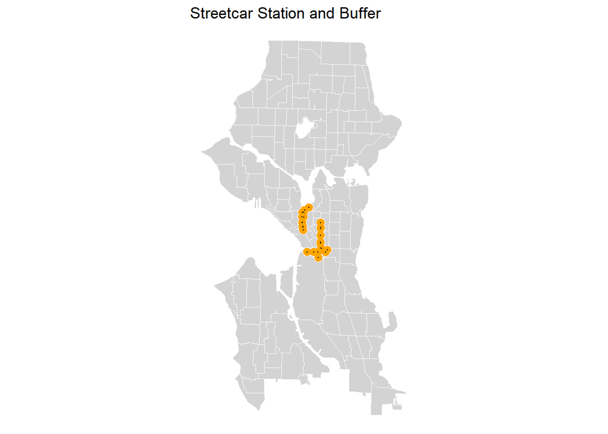

```r
## Street Car Station and Buffer
ggplot() +
  geom_sf(data = tracts, fill = "lightgrey", col = "white") +
  geom_sf(data = streetcar.Buffer, fill = "orange", col = "white") +
  geom_sf(data = streetcar, col = "black", show.legend = "point", size = .25) +
  labs(title = "Streetcar Station and Buffer") +
  theme_void()
```

```r
## Hospital
Hospital_clipped <- st_intersection(Hospital, tracts)
```

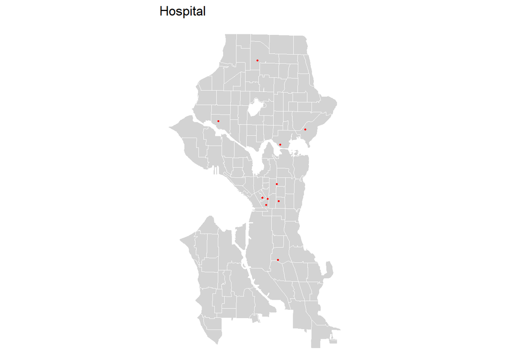

```r
ggplot() +
  geom_sf(data = tracts, fill = "lightgrey", col = "white") +
  geom_sf(data = Hospital_clipped, size = .5, color = "red") +
  labs(title = "Hospital") +
  theme_void()
```

```r
## MedIncome
Demo_clipped <- st_intersection(Demo, tracts)
```

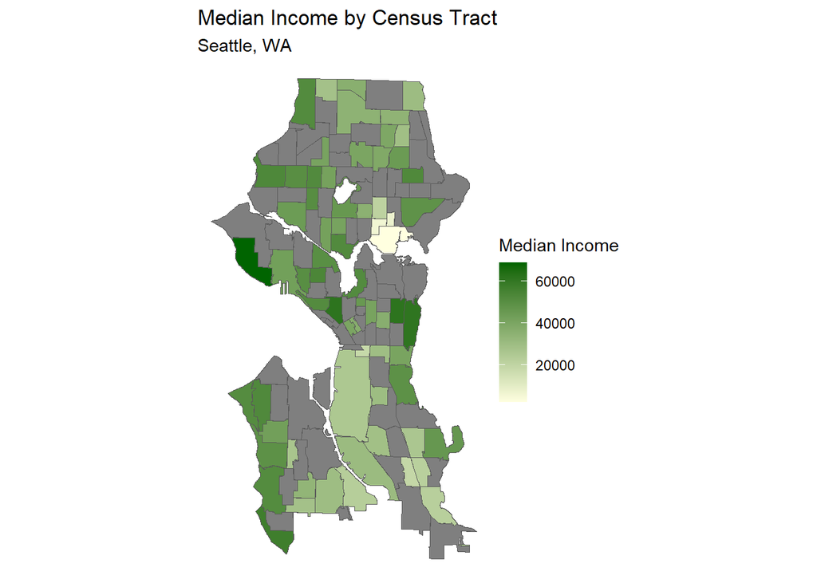

```r
ggplot(data = Demo_clipped) +
  geom_sf(aes(fill = MedIncome)) +  # Use MedIncome for the fill color
  scale_fill_gradient(low = "lightyellow", high = "darkgreen",
                      name = "Median Income") +  # Adjust color gradient as needed
  labs(title = "Median Income by Census Tract",
       subtitle = "Seattle, WA") +
    theme_void()
```

# Analysis Variables

## Analyzing associations

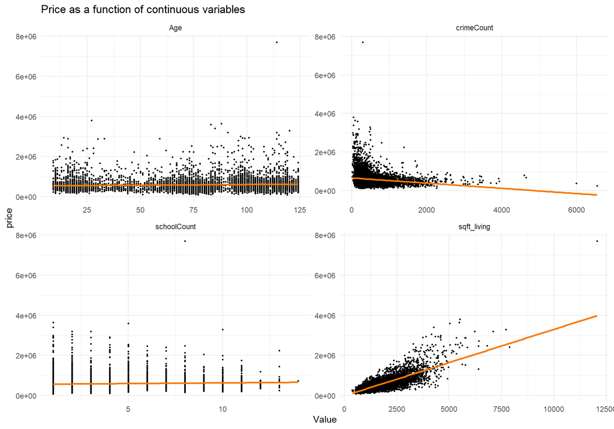

```r
# Remove geometry column (if present), calculate Age, and select relevant variables
Seattle <- st_drop_geometry(Seattle.sf_tracts2) %>%
  select(price, sqft_living, Age, crimeCount, schoolCount) %>%
  filter(Age < 500)


Seattle_long <- gather(Seattle, Variable, Value, -price)

# Create scatterplot with linear regression lines for each variable
ggplot(Seattle_long, aes(Value, price)) +
  geom_point(size = .5) +
  geom_smooth(method = "lm", se = FALSE, colour = "#FA7800") +
  facet_wrap(~Variable, ncol = 2, scales = "free") +
  labs(title = "Price as a function of continuous variables") +
  theme_minimal()
```

## Correlation matrix

A correlation matrix gives us the pairwise correlation of each set of features in our data. It is usually advisable to include the target/outcome variable in this so we can understand which features are related to it.

Some things to notice in this code; we use `select_if()` to select only the features that are numeric. This is really handy when you don’t want to type or hard-code the names of your features; `ggcorrplot()` is a function from the `ggcorrplot` package.

**Let’s take a few minutes to interpret this**

```r
# Select only numeric variables and remove rows with missing values
numericVars <- Seattle.sf_tracts2 %>%
  st_drop_geometry() %>%  # Remove geometry column if present
  select_if(is.numeric) %>%  # Select only numeric variables
  na.omit()  # Remove rows with missing values

# Calculate correlation matrix
correlation_matrix <- cor(numericVars)
```

[output not shown]

[output cut: 8 more lines]

[output not shown]

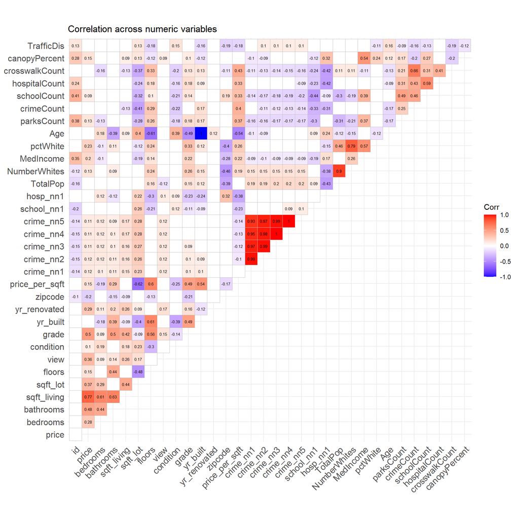

```r
# Create correlation plot
ggcorrplot(
  correlation_matrix,  # Correlation matrix
  p.mat = cor_pmat(numericVars),  # p-values for significance
  colors = c("blue", "white", "red"),  # Custom color palette
  type = "upper",  # Lower triangle of the correlation matrix
  insig = "blank",  # Hide insignificant correlations
  lab = TRUE,
  lab_size = 2
) +
labs(title = "Correlation across numeric variables")  # Set plot title
```

```r
# yet another way to plot the correlation plot using the corrr library
# numericVars %>%
#   correlate() %>%
#   autoplot() +
#   geom_text(aes(label = round(r,digits=2)),size = 2)

# Compute correlations
cor_result <- numericVars %>%
  correlate()
```

```
## Correlation computed with
## • Method: 'pearson'
## • Missing treated using: 'pairwise.complete.obs'
```

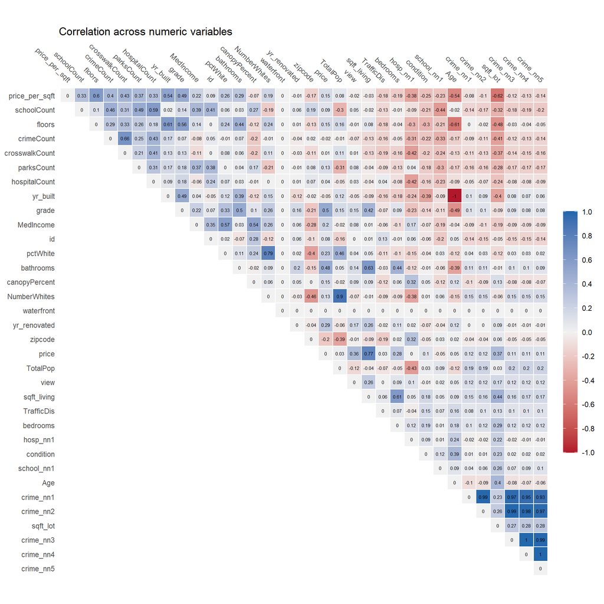

```r
# Replace NA values with 0
cor_result[is.na(cor_result)] <- 0

cor_result %>%
  autoplot() +
  geom_text(aes(label = round(r,digits=2)),size = 2) +
labs(title = "Correlation across numeric variables")  # Set plot title
```

## Multivariate Regression

```r
##Baseline Model Reg0
Seattle_final_0 <- st_drop_geometry(Seattle.sf_tracts2)%>%
  select(-contains("Buffer"), -contains("distance"), -contains("date"), -yr_built, -canopy, -quintiles)%>%
  filter(price <= 2000000)

reg0 <- lm(price ~ ., data = Seattle_final_0)

summary_reg0 <- summary(reg0)

## Kable show summary of the model Reg0
coef_table0 <- as.data.frame(summary_reg0$coefficients)
coef_table0$significance <- ifelse(coef_table0$`Pr(>|t|)` < 0.001, '***',
                                    ifelse(coef_table0$`Pr(>|t|)` < 0.01, '**',
                                      ifelse(coef_table0$`Pr(>|t|)` < 0.05, '*',
                                        ifelse(coef_table0$`Pr(>|t|)` < 0.1, '.', ''))))
coef_table0$p_value <- paste0(round(coef_table0$`Pr(>|t|)`, digits = 3), coef_table0$significance)
coef_table0$'t value' <- round(coef_table0$'t value', digits = 2)
coef_table0$'Std. Error' <- round(coef_table0$'Std. Error', digits = 2)
coef_table0$Estimate <- round(coef_table0$Estimate, digits = 2)

coef_table0 %>%
  select(-significance, -`Pr(>|t|)`) %>%
  kable(align = "r") %>%
  kable_styling(bootstrap_options = c("striped", "hover", "condensed")) %>%
  footnote(general_title = "\n", general = "Table x")
```

|  | Estimate | Std. Error | t value | p_value |
| --- | --- | --- | --- | --- |
| (Intercept) | 180027407.04 | 44784927.80 | 4.02 | 0*** |
| id | 0.00 | 0.00 | 0.19 | 0.849 |
| bedrooms | 6577.73 | 6638.55 | 0.99 | 0.322 |
| bathrooms | 3111.37 | 9695.93 | 0.32 | 0.748 |
| sqft_living | 103.53 | 13.04 | 7.94 | 0*** |
| sqft_lot | 20.62 | 2.98 | 6.92 | 0*** |
| floors | 17629.76 | 11321.18 | 1.56 | 0.12 |
| view | 54632.01 | 10457.77 | 5.22 | 0*** |
| condition | 23947.35 | 7082.89 | 3.38 | 0.001*** |
| grade | 52521.04 | 7966.09 | 6.59 | 0*** |
| yr_renovated | 35.41 | 12.23 | 2.89 | 0.004** |
| zipcode | -1837.18 | 456.22 | -4.03 | 0*** |
| price_per_sqft | 310.97 | 40.82 | 7.62 | 0*** |
| crime_nn1 | 284.74 | 628.46 | 0.45 | 0.651 |
| crime_nn2 | 22.96 | 1722.20 | 0.01 | 0.989 |
| crime_nn3 | 3472.81 | 3217.54 | 1.08 | 0.281 |
| crime_nn4 | -7865.75 | 3778.21 | -2.08 | 0.038* |
| crime_nn5 | 4186.34 | 2049.45 | 2.04 | 0.042* |
| school_nn1 | 11.33 | 5.34 | 2.12 | 0.034* |
| hosp_nn1 | 19.28 | 5.49 | 3.51 | 0*** |
| streetcar.stationTRUE | -13559.97 | 42506.28 | -0.32 | 0.75 |
| TotalPop | -108.26 | 18.85 | -5.74 | 0*** |
| NumberWhites | 159.91 | 25.14 | 6.36 | 0*** |
| MedIncome | 0.17 | 0.80 | 0.21 | 0.833 |
| pctWhite | -657228.23 | 144153.47 | -4.56 | 0*** |
| Age | 811.77 | 184.53 | 4.40 | 0*** |
| parksCount | 15322.50 | 4563.84 | 3.36 | 0.001*** |
| crimeCount | 6.42 | 8.28 | 0.77 | 0.439 |
| schoolCount | 5343.41 | 2570.24 | 2.08 | 0.038* |
| hospitalCount | 848.74 | 7994.40 | 0.11 | 0.915 |
| crosswalkCount | 1072.59 | 552.54 | 1.94 | 0.053. |
| canopyPercent | 3141.51 | 774.36 | 4.06 | 0*** |
| TrafficDis | 23.83 | 18.93 | 1.26 | 0.209 |

```r
## Finalized Model Reg1
Seattle_final <- Seattle_final_0 %>%
  select(id, Age, price, bedrooms, bathrooms, sqft_living, waterfront, view, condition, grade,
         crimeCount, hosp_nn1, schoolCount, canopyPercent, parksCount, crosswalkCount, TrafficDis,
         pctWhite, MedIncome)%>%
  mutate_all(~replace(., is.na(.), 0))

reg1 <- lm(price ~ ., data = Seattle_final)

summary_reg1 <- summary(reg1)

## Kable show summary of the model Reg0

coef_table1 <- as.data.frame(summary_reg1$coefficients)
coef_table1$significance <- ifelse(coef_table1$`Pr(>|t|)` < 0.001, '***',
                                    ifelse(coef_table1$`Pr(>|t|)` < 0.01, '**',
                                      ifelse(coef_table1$`Pr(>|t|)` < 0.05, '*',
                                        ifelse(coef_table1$`Pr(>|t|)` < 0.1, '.', ''))))
coef_table1$p_value <- paste0(round(coef_table1$`Pr(>|t|)`, digits = 3), coef_table1$significance)
coef_table1$'t value' <- round(coef_table1$'t value', digits = 2)
coef_table1$'Std. Error' <- round(coef_table1$'Std. Error', digits = 2)
coef_table1$Estimate <- round(coef_table1$Estimate, digits = 2)

coef_table1 %>%
  select(-significance, -`Pr(>|t|)`) %>%
  kable(align = "r") %>%
  kable_styling(bootstrap_options = c("striped", "hover", "condensed")) %>%
  footnote(general_title = "\n", general = "Table x")
```

|  | Estimate | Std. Error | t value | p_value |
| --- | --- | --- | --- | --- |
| (Intercept) | -859802.48 | 21857.58 | -39.34 | 0*** |
| id | 0.00 | 0.00 | -2.73 | 0.006** |
| Age | 1463.96 | 65.57 | 22.33 | 0*** |
| bedrooms | -11020.07 | 2032.27 | -5.42 | 0*** |
| bathrooms | 9825.31 | 3417.97 | 2.87 | 0.004** |
| sqft_living | 156.47 | 4.10 | 38.14 | 0*** |
| waterfront | 385451.29 | 30144.40 | 12.79 | 0*** |
| view | 35780.31 | 2373.73 | 15.07 | 0*** |
| condition | 16450.25 | 2579.17 | 6.38 | 0*** |
| grade | 102519.91 | 2675.35 | 38.32 | 0*** |
| crimeCount | -23.97 | 4.80 | -4.99 | 0*** |
| hosp_nn1 | -4.20 | 0.32 | -13.01 | 0*** |
| schoolCount | 1553.99 | 703.66 | 2.21 | 0.027* |
| canopyPercent | 604.60 | 214.15 | 2.82 | 0.005** |
| parksCount | 15627.43 | 999.52 | 15.63 | 0*** |
| crosswalkCount | 769.03 | 228.84 | 3.36 | 0.001*** |
| TrafficDis | 42.26 | 5.33 | 7.93 | 0*** |
| pctWhite | 320400.22 | 9766.27 | 32.81 | 0*** |
| MedIncome | -0.28 | 0.07 | -3.76 | 0*** |

```r
model_summary <- data.frame(
  Statistic = c("Multiple R-squared", "Adjusted R-squared", "F-statistic"),
  Value = c(
    summary_reg1$r.squared,
    summary_reg1$adj.r.squared,
    summary_reg1$fstatistic[1]
  )
)

model_summary %>%
  kable() %>%
  kable_styling(bootstrap_options = c("striped", "hover", "condensed"))%>%
  footnote(general_title = "\n", general = "Table x")
```

| Statistic | Value |
| --- | --- |
| Multiple R-squared | 0.7577989 |
| Adjusted R-squared | 0.7571433 |
| F-statistic | 1155.9179745 |

#Residual

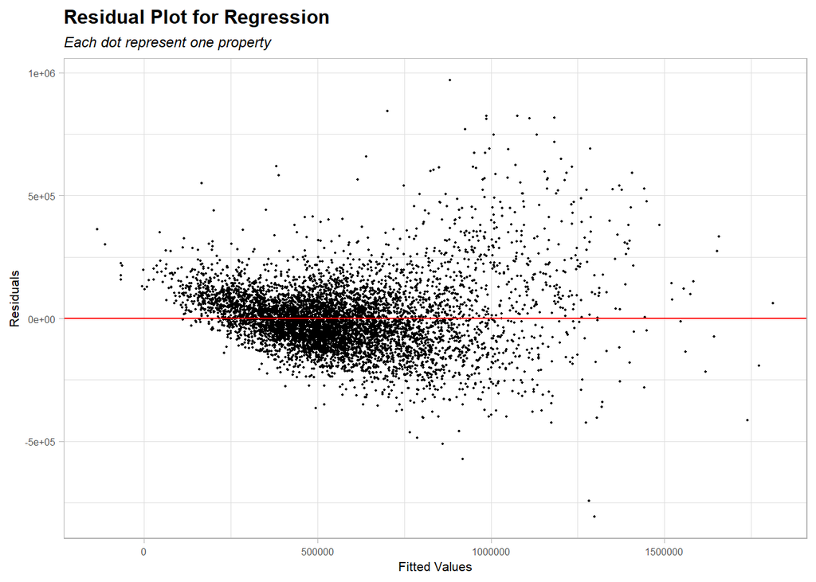

```r
residuals_df <- data.frame(Residuals = resid(reg1), Fitted = fitted(reg1))
ggplot(residuals_df, aes(x = Fitted, y = Residuals)) +
  geom_point(size = 0.4, color = "black") +
  geom_hline(yintercept = 0, color = "red") +
  labs(title = "Residual Plot for Regression",
       subtitle = "Each dot represent one property ",
       x = "Fitted Values",
       y = "Residuals") +
  theme_light() +
  theme(plot.subtitle = element_text(size = 9,face = "italic"),
        plot.title = element_text(size = 12, face = "bold"),
        axis.text.x=element_text(size=6),
        axis.text.y=element_text(size=6),
        axis.title=element_text(size=8))
```

#Training and Testing Datasets

```r
# Split the dataset into a training set and a test set using stratified sampling
inTrain <- createDataPartition(
              y = paste(Seattle_final$sqft_lot, Seattle_final$view,
                        Seattle_final$yr_built, Seattle_final$school_nn1),
              p = .60, list = FALSE)  # Create a vector of indices for the training set

# Subset the dataset to create the training set
Seattle.training <- Seattle_final[inTrain,]  # Training set
# Subset the dataset to create the test set
Seattle.test <- Seattle_final[-inTrain,]     # Test set

# Fit a linear regression model to predict Sales Price using selected predictors
reg.training <-
  lm(price ~ ., data = as.data.frame(Seattle.training))

summary_training <- summary(reg.training)

# Make predictions on the test set and evaluate model performance

Seattle.test <-
  Seattle.test %>%  # Pipe the test set into the following operations
  # Add a column indicating the type of regression model used
  mutate(Regression = "Baseline Regression",
         # Predict sale prices using the trained regression model
         SalePrice.Predict = predict(reg.training, Seattle.test),
         # Calculate the difference between predicted and actual sale prices
         SalePrice.Error = SalePrice.Predict - price,
         # Calculate the absolute difference between predicted and actual sale prices
         SalePrice.AbsError = abs(SalePrice.Predict - price),
         # Calculate the absolute percentage error
         SalePrice.APE = (abs(SalePrice.Predict - price)) / price) %>%
  filter(price < 5000000)  # Filter out records with SalePrice greater than $5,000,000
```

## examine the model (diagnose)

```r
#MAE
mean(Seattle.test$SalePrice.AbsError, na.rm = T)
```

```
## [1] 95955.81
```

```r
## absolute difference between the predicted value (often a forecast or an estimate produced by a model) and the actual value observed.
## larger value means larger error, less accurate of the model

#MAPE
mean(Seattle.test$SalePrice.APE, na.rm = T)
```

```
## [1] 0.1822201
```

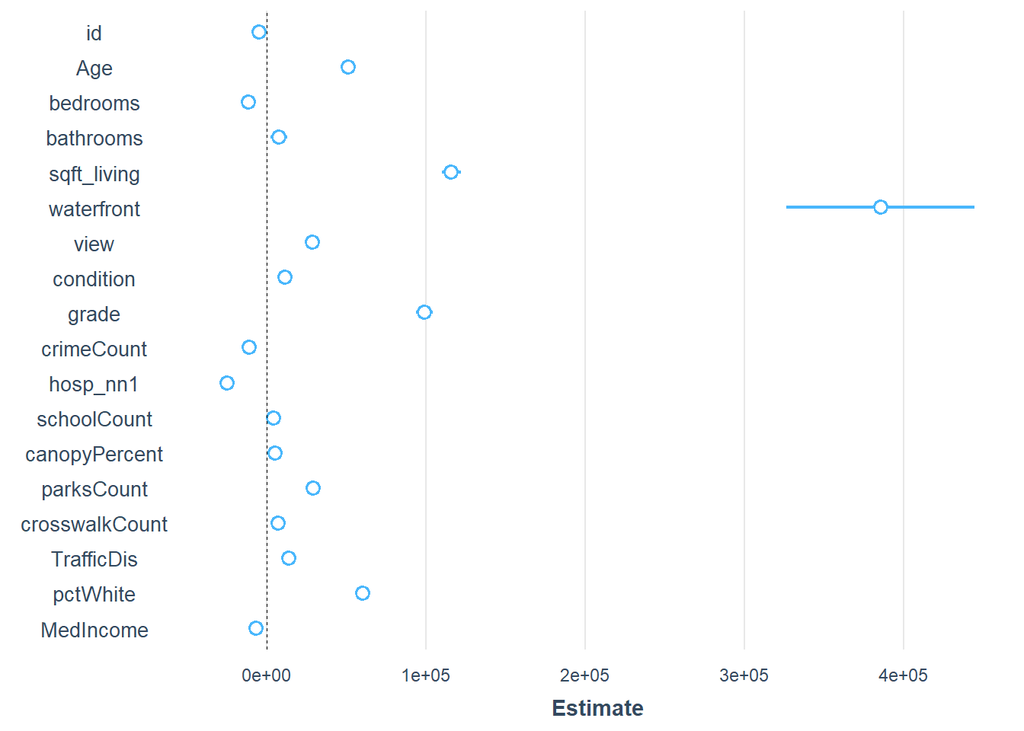

```r
## Mean Absolute Percentage Error
## the error as a percentage of the actual values

## Plot coefficients
plot_summs(reg1, scale = TRUE)
```

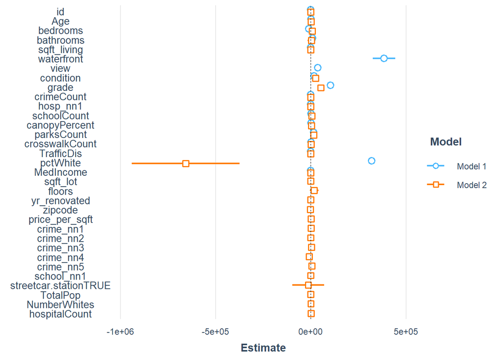

```r
## plot multiple model coeffs, use another model for comparison.
plot_summs(reg1, reg0)
```

# cross validation

```r
# Load necessary libraries

# Define the control parameters for k-fold cross-validation
control <- trainControl(method = "cv",    # Use k-fold cross-validation
                        number = 10,      # Number of folds
                        verboseIter = TRUE,  # Show verbose output
                        returnData = FALSE,  # Don't return resampled data
                        savePredictions = TRUE,  # Save predictions
                        classProbs = FALSE,  # Don't compute class probabilities
                        summaryFunction = defaultSummary)  # Use default summary function

# Train the linear regression model using k-fold cross-validation
lm_cv <- train(price ~ .,  # Formula for the linear regression model
               data = Seattle_final,  # Dataset
               method = "lm",           # Specify "lm" for linear regression
               trControl = control)     # Use the defined control parameters
# View the cross-validation results
print(lm_cv)
```

```
## Linear Regression
##
## No pre-processing
## Resampling: Cross-Validated (10 fold)
## Summary of sample sizes: 6002, 6003, 5999, 6002, 6003, 6002, ...
## Resampling results:
##
##   RMSE      Rsquared   MAE
##   135909.5  0.7561099  97118.67
##
## Tuning parameter 'intercept' was held constant at a value of TRUE
```

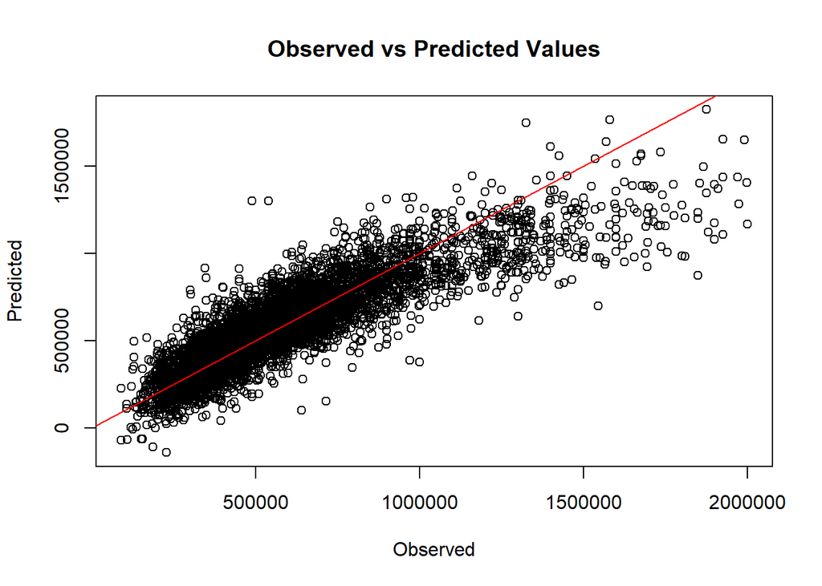

```
## integer(0)
```

```r
# Plot observed versus predicted values
plot(lm_cv$pred$obs, lm_cv$pred$pred,
     xlab = "Observed", ylab = "Predicted",
     main = "Observed vs Predicted Values") +
     abline(0, 1, col = "red")
```

# Distribution of Sale Price Error Testing Set

```r
Seattle.test_join <- left_join(Seattle.test, housingData, join_by(id == id))
```

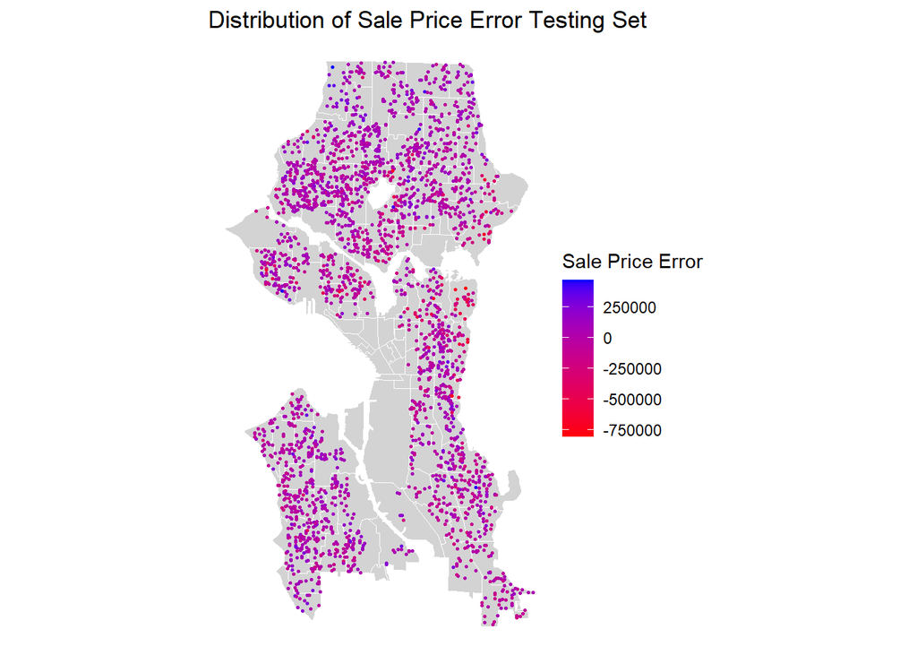

```r
Seattle.test_withgeo <-
  Seattle.test_join %>%
  st_as_sf(coords = c("long", "lat"), crs = 4326, agr = "constant") %>%
  st_transform(crs = 2926)

Seattle.test_withgeo$SalePrice.Error <- round(Seattle.test_withgeo$SalePrice.Error, digits = 2)

ggplot()+
  geom_sf(data = tracts, fill = "lightgrey", col = "white") +
  geom_sf(data=Seattle.test_withgeo, aes(colour = Seattle.test_withgeo$SalePrice.Error), size=0.5)+
  scale_color_continuous(high = "blue", low = "red", name= "Sale Price Error ") +
  labs(title = "Distribution of Sale Price Error Testing Set") +
  theme_void()
```

#Mean Absolute Percentage Error By Neighborhood

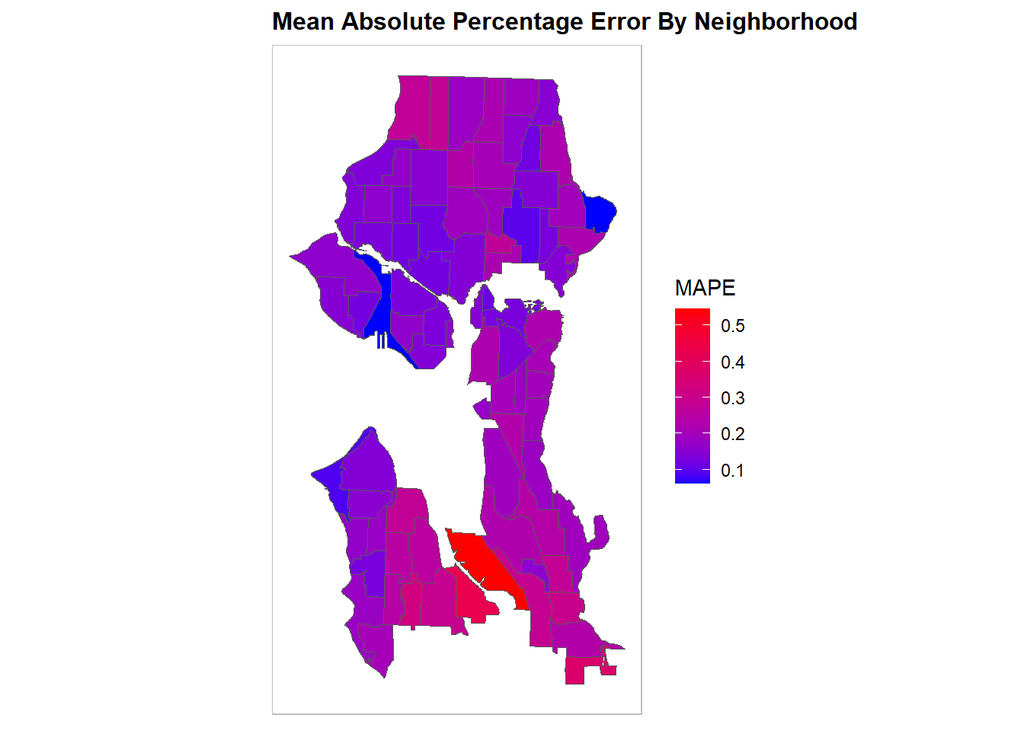

```r
to_plot <- st_intersection(Seattle.test_withgeo, neighborhood %>% dplyr::select("S_HOOD")) %>%
  st_drop_geometry() %>%
  group_by(S_HOOD) %>%
  summarise(mean.MAPE = mean(SalePrice.APE, na.rm = T)) %>%
  left_join(neighborhood) %>%
  st_sf()
to_plot %>%
  ggplot() +
      geom_sf(aes(fill = mean.MAPE)) +
  scale_fill_continuous(low = "blue", high = "red", name= "MAPE") +
  theme(
        axis.text.x=element_blank(),
        axis.ticks.x=element_blank(),
        axis.text.y=element_blank(),
        axis.ticks.y=element_blank(),
        plot.title = element_text(size = 12, face = "bold"),
        panel.background = element_blank(),
        panel.border = element_rect(colour = "grey", fill=NA, size=0.4)
        ) +
  labs(title = "Mean Absolute Percentage Error By Neighborhood")
```

#RMSE, MAE

```r
# Set up leave-one-out cross-validation
control <- trainControl(method = "LOOCV",     # Use leave-one-out cross-validation
                        number = nrow(Seattle_final),  # Number of folds = number of observations
                        verboseIter = TRUE,  # Show verbose output
                        returnData = FALSE,  # Don't return resampled data
                        savePredictions = TRUE,  # Save predictions
                        classProbs = FALSE,  # Don't compute class probabilities
                        summaryFunction = defaultSummary)  # Use default summary function

# Train the linear regression model using leave-one-out cross-validation
lm_loocv <- train(price ~ .,  # Formula for the linear regression model
                  data = Seattle_final,  # Dataset
                  method = "lm",           # Specify "lm" for linear regression
                  trControl = control)     # Use the defined control parameters
# 6669 fold in total
```

```r
# View the cross-validation results
loocv_results <- lm_loocv['results']
statistic_summary <- do.call(rbind, loocv_results) %>% select(-contains("intercept"))


kbl(statistic_summary) %>%
  kable_styling(bootstrap_options = "striped", full_width = T, position = "left")
```

|  | RMSE | Rsquared | MAE |
| --- | --- | --- | --- |
| results | 136094.4 | 0.7556509 | 97137.61 |